# R Notebook

## Regression of Population on NO2

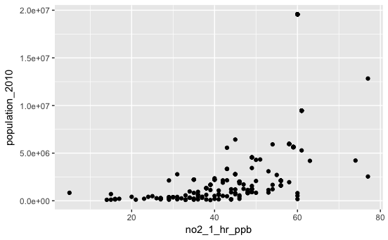

```r
ggplot(df, mapping = aes(no2_1_hr_ppb, population_2010)) + geom_point()
```

```r
cor.test(df$no2_1_hr_ppb, df$population_2010)
```

```
    Pearson's product-moment correlation

data:  df$no2_1_hr_ppb and df$population_2010
t = 11.349, df = 235, p-value < 2.2e-16
alternative hypothesis: true correlation is not equal to 0
95 percent confidence interval:
 0.5059275 0.6715136
sample estimates:
     cor
0.594998
```

```r
attach(df)
lmModel1 <- lm(population_2010 ~ no2_1_hr_ppb)
```

```
Dropping 293 rows with missing values
```

```r
summary(lmModel1)
```

```
Call:
lm(formula = population_2010 ~ no2_1_hr_ppb)

Residuals:
     Min       1Q   Median       3Q      Max
-6411708 -1948257  -158243   464036 13702537

Coefficients:
             Estimate Std. Error t value Pr(>|t|)
(Intercept)  -5042128     738491  -6.828  7.3e-11 ***
no2_1_hr_ppb   181783      16018  11.349  < 2e-16 ***
---
Signif. codes:  0 ‘***’ 0.001 ‘**’ 0.01 ‘*’ 0.05 ‘.’ 0.1 ‘ ’ 1

Residual standard error: 3327000 on 235 degrees of freedom
  (293 observations deleted due to missingness)
Multiple R-squared:  0.354, Adjusted R-squared:  0.3513
F-statistic: 128.8 on 1 and 235 DF,  p-value: < 2.2e-16
```

### Unfortunately this is not a viable prediction model, it’s $R^{2}$ is only 0.354. We will try adding a quadratic term to the model.

```r
lmModel3 <- lm(population_2010 ~ no2_1_hr_ppb + I(no2_1_hr_ppb^2))
```

```
Dropping 293 rows with missing values
```

```r
summary(lmModel3)
```

```
Call:
lm(formula = population_2010 ~ no2_1_hr_ppb + I(no2_1_hr_ppb^2))

Residuals:
      Min        1Q    Median        3Q       Max
-11573642  -1161833    -16360    308018  12988327

Coefficients:
                   Estimate Std. Error t value Pr(>|t|)
(Intercept)       2551064.8  1603563.4   1.591  0.11299
no2_1_hr_ppb      -226072.0    78970.3  -2.863  0.00458 **
I(no2_1_hr_ppb^2)    4886.8      928.5   5.263 3.21e-07 ***
---
Signif. codes:  0 ‘***’ 0.001 ‘**’ 0.01 ‘*’ 0.05 ‘.’ 0.1 ‘ ’ 1

Residual standard error: 3153000 on 234 degrees of freedom
  (293 observations deleted due to missingness)
Multiple R-squared:  0.4224,    Adjusted R-squared:  0.4175
F-statistic: 85.56 on 2 and 234 DF,  p-value: < 2.2e-16
```

### This model is slightly better but we should try taking the log of the population instead.

## Regression of Log(Population) on NO2

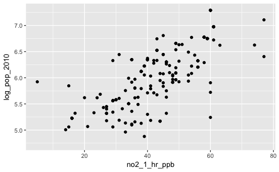

```r
ggplot(df, mapping = aes(no2_1_hr_ppb, log_pop_2010)) + geom_point()
```

```r
cor.test(df$no2_1_hr_ppb, log_pop_2010)
```

```
    Pearson's product-moment correlation

data:  df$no2_1_hr_ppb and log_pop_2010
t = 18.798, df = 235, p-value < 2.2e-16
alternative hypothesis: true correlation is not equal to 0
95 percent confidence interval:
 0.7184977 0.8212959
sample estimates:
      cor
0.7749727
```

```r
lmModel2 <- lm(log_pop_2010 ~ no2_1_hr_ppb)
```

```
Dropping 293 rows with missing values
```

```r
summary(lmModel2)
```

```
Call:
lm(formula = log_pop_2010 ~ no2_1_hr_ppb)

Residuals:
     Min       1Q   Median       3Q      Max
-1.41557 -0.21335  0.08411  0.22211  1.15907

Coefficients:
             Estimate Std. Error t value Pr(>|t|)
(Intercept)  4.591821   0.084435   54.38   <2e-16 ***
no2_1_hr_ppb 0.034427   0.001831   18.80   <2e-16 ***
---
Signif. codes:  0 ‘***’ 0.001 ‘**’ 0.01 ‘*’ 0.05 ‘.’ 0.1 ‘ ’ 1

Residual standard error: 0.3804 on 235 degrees of freedom
  (293 observations deleted due to missingness)
Multiple R-squared:  0.6006,    Adjusted R-squared:  0.5989
F-statistic: 353.4 on 1 and 235 DF,  p-value: < 2.2e-16
```

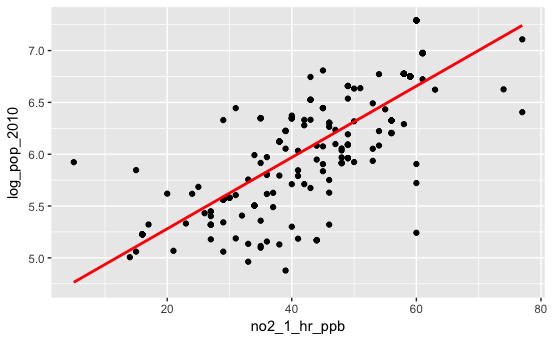

```r
grid2 <- df %>% data_grid(no2_1_hr_ppb = seq_range(no2_1_hr_ppb, 20)) %>%
  add_predictions(lmModel2, "log_pop_2010")
ggplot(df, mapping = aes(no2_1_hr_ppb, log_pop_2010)) +
  geom_point() +
  geom_line(data = grid2, colour = "red", size = 1)
```

### This prediction model works much better and accounts for roughly 60% of the variance in the data. Let’s try looking at other variables.

## Regression of Log(Population) on O3 pollution and on per capita income.

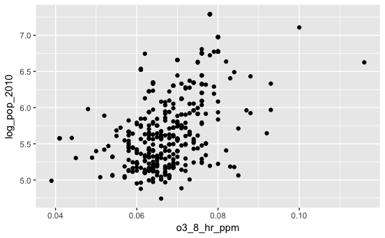

```r
ggplot(df, mapping = aes(o3_8_hr_ppm, log_pop_2010)) + geom_point()
```

```r
cor.test(o3_8_hr_ppm, log_pop_2010)
```

```
    Pearson's product-moment correlation

data:  o3_8_hr_ppm and log_pop_2010
t = 13.953, df = 466, p-value < 2.2e-16
alternative hypothesis: true correlation is not equal to 0
95 percent confidence interval:
 0.4755868 0.6037631
sample estimates:
      cor
0.5428282
```

```r
lmModel4 <- lm(log_pop_2010 ~ o3_8_hr_ppm + I(o3_8_hr_ppm^2 ))
```

```
Dropping 62 rows with missing values
```

```r
summary(lmModel4)
```

```
Call:
lm(formula = log_pop_2010 ~ o3_8_hr_ppm + I(o3_8_hr_ppm^2))

Residuals:
     Min       1Q   Median       3Q      Max
-1.47606 -0.35821 -0.05157  0.32164  1.21817

Coefficients:
                 Estimate Std. Error t value Pr(>|t|)
(Intercept)        4.5471     0.7024   6.474 2.43e-10 ***
o3_8_hr_ppm       -1.2229    20.0605  -0.061   0.9514
I(o3_8_hr_ppm^2) 274.7226   143.4915   1.915   0.0562 .
---
Signif. codes:  0 ‘***’ 0.001 ‘**’ 0.01 ‘*’ 0.05 ‘.’ 0.1 ‘ ’ 1

Residual standard error: 0.4871 on 465 degrees of freedom
  (62 observations deleted due to missingness)
Multiple R-squared:  0.3002,    Adjusted R-squared:  0.2972
F-statistic: 99.73 on 2 and 465 DF,  p-value: < 2.2e-16
```

### The $R^2$ statistic is too low on this model to be a viable predictor.

### Let’s look at how per capita income affects the population growth:

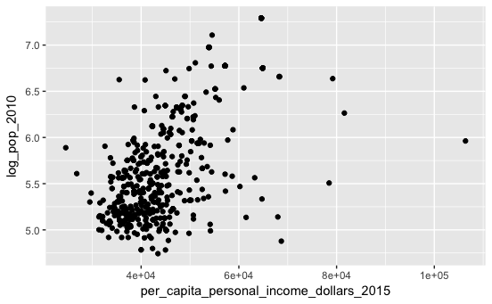

```r
ggplot(df, mapping = aes(per_capita_personal_income_dollars_2015, log_pop_2010)) + geom_point()
```

```r
cor.test(per_capita_personal_income_dollars_2015, log_pop_2010)
```

```
    Pearson's product-moment correlation

data:  per_capita_personal_income_dollars_2015 and log_pop_2010
t = 18.284, df = 526, p-value < 2.2e-16
alternative hypothesis: true correlation is not equal to 0
95 percent confidence interval:
 0.5682538 0.6728977
sample estimates:
      cor
0.6233589
```

```r
lmModel5 <- lm(log_pop_2010 ~ per_capita_personal_income_dollars_2015 + I(per_capita_personal_income_dollars_2015^2))
```

```
Dropping 2 rows with missing values
```

```r
summary(lmModel5)
```

```
Call:
lm(formula = log_pop_2010 ~ per_capita_personal_income_dollars_2015 +
    I(per_capita_personal_income_dollars_2015^2))

Residuals:
     Min       1Q   Median       3Q      Max
-1.68570 -0.28958 -0.01379  0.32812  1.36104

Coefficients:
                                               Estimate Std. Error t value Pr(>|t|)
(Intercept)                                   2.649e+00  3.037e-01   8.722  < 2e-16 ***
per_capita_personal_income_dollars_2015       9.152e-05  1.194e-05   7.667 8.58e-14 ***
I(per_capita_personal_income_dollars_2015^2) -5.026e-10  1.140e-10  -4.408 1.27e-05 ***
---
Signif. codes:  0 ‘***’ 0.001 ‘**’ 0.01 ‘*’ 0.05 ‘.’ 0.1 ‘ ’ 1

Residual standard error: 0.4524 on 525 degrees of freedom
  (2 observations deleted due to missingness)
Multiple R-squared:  0.4104,    Adjusted R-squared:  0.4081
F-statistic: 182.7 on 2 and 525 DF,  p-value: < 2.2e-16
```

### Both factors O3 pollution and per captia income of the area seem to be bad predictors of population size by themselves.

```r
lmModel6 <- lm(log_pop_2010 ~ o3_8_hr_ppm * per_capita_personal_income_dollars_2015)
```

```
Dropping 62 rows with missing values
```

```r
summary(lmModel6)
```

```
Call:
lm(formula = log_pop_2010 ~ o3_8_hr_ppm * per_capita_personal_income_dollars_2015)

Residuals:
     Min       1Q   Median       3Q      Max
-2.97545 -0.26729  0.02566  0.26912  1.07089

Coefficients:
                                                      Estimate Std. Error t value Pr(>|t|)
(Intercept)                                          5.311e+00  6.456e-01   8.226 1.96e-15 ***
o3_8_hr_ppm                                         -1.229e+01  9.124e+00  -1.347   0.1787
per_capita_personal_income_dollars_2015             -3.084e-05  1.397e-05  -2.208   0.0277 *
o3_8_hr_ppm:per_capita_personal_income_dollars_2015  8.619e-04  1.936e-04   4.451 1.07e-05 ***
---
Signif. codes:  0 ‘***’ 0.001 ‘**’ 0.01 ‘*’ 0.05 ‘.’ 0.1 ‘ ’ 1

Residual standard error: 0.3952 on 464 degrees of freedom
  (62 observations deleted due to missingness)
Multiple R-squared:  0.5403,    Adjusted R-squared:  0.5373
F-statistic: 181.8 on 3 and 464 DF,  p-value: < 2.2e-16
```

### This is a viable prediction model however the p-value for the o3 coefficient is too high. We will drop that term from the model altogether.

```r
lmModel7 <- lm(log_pop_2010 ~ per_capita_personal_income_dollars_2015 + o3_8_hr_ppm:per_capita_personal_income_dollars_2015)
```

```
Dropping 62 rows with missing values
```

```r
summary(lmModel7)
```

```
Call:
lm(formula = log_pop_2010 ~ per_capita_personal_income_dollars_2015 +
    o3_8_hr_ppm:per_capita_personal_income_dollars_2015)

Residuals:
     Min       1Q   Median       3Q      Max
-2.74326 -0.26809  0.02631  0.28197  1.06066

Coefficients:
                                                      Estimate Std. Error t value Pr(>|t|)
(Intercept)                                          4.451e+00  9.558e-02  46.564  < 2e-16 ***
per_capita_personal_income_dollars_2015             -1.299e-05  4.408e-06  -2.946  0.00338 **
per_capita_personal_income_dollars_2015:o3_8_hr_ppm  6.090e-04  4.743e-05  12.840  < 2e-16 ***
---
Signif. codes:  0 ‘***’ 0.001 ‘**’ 0.01 ‘*’ 0.05 ‘.’ 0.1 ‘ ’ 1

Residual standard error: 0.3956 on 465 degrees of freedom
  (62 observations deleted due to missingness)
Multiple R-squared:  0.5385,    Adjusted R-squared:  0.5365
F-statistic: 271.3 on 2 and 465 DF,  p-value: < 2.2e-16
```

## Regression of Population on NO2 pollution, O3 pollution, and per capita income of the state.

```r
lmModel8 <- lm(log_pop_2010 ~ no2_1_hr_ppb + per_capita_personal_income_dollars_2015 + o3_8_hr_ppm:per_capita_personal_income_dollars_2015)
```

```
Dropping 293 rows with missing values
```

```r
summary(lmModel8)
```

```
Call:
lm(formula = log_pop_2010 ~ no2_1_hr_ppb + per_capita_personal_income_dollars_2015 +
    o3_8_hr_ppm:per_capita_personal_income_dollars_2015)

Residuals:
     Min       1Q   Median       3Q      Max
-1.39245 -0.19151 -0.02781  0.27575  0.88171

Coefficients:
                                                     Estimate Std. Error t value Pr(>|t|)
(Intercept)                                         3.984e+00  1.286e-01  30.982  < 2e-16 ***
no2_1_hr_ppb                                        2.069e-02  2.564e-03   8.072 3.68e-14 ***
per_capita_personal_income_dollars_2015             4.952e-06  5.684e-06   0.871 0.384544
per_capita_personal_income_dollars_2015:o3_8_hr_ppm 2.717e-04  7.765e-05   3.499 0.000559 ***
---
Signif. codes:  0 ‘***’ 0.001 ‘**’ 0.01 ‘*’ 0.05 ‘.’ 0.1 ‘ ’ 1

Residual standard error: 0.3271 on 233 degrees of freedom
  (293 observations deleted due to missingness)
Multiple R-squared:  0.7072,    Adjusted R-squared:  0.7034
F-statistic: 187.6 on 3 and 233 DF,  p-value: < 2.2e-16
```

### This becomes a much stronger predictive model that explains 71% of the variance, however we see that the per capita coefficient has a very high p-value.

```r
lmModel9 <- lm(log_pop_2010 ~ no2_1_hr_ppb +  o3_8_hr_ppm:per_capita_personal_income_dollars_2015)
```

```
Dropping 293 rows with missing values
```

```r
summary(lmModel9)
```

```
Call:
lm(formula = log_pop_2010 ~ no2_1_hr_ppb + o3_8_hr_ppm:per_capita_personal_income_dollars_2015)

Residuals:
     Min       1Q   Median       3Q      Max
-1.33924 -0.18251 -0.02682  0.26573  0.87828

Coefficients:
                                                     Estimate Std. Error t value Pr(>|t|)
(Intercept)                                         4.062e+00  9.275e-02  43.796  < 2e-16 ***
no2_1_hr_ppb                                        1.963e-02  2.253e-03   8.712 5.53e-16 ***
o3_8_hr_ppm:per_capita_personal_income_dollars_2015 3.316e-04  3.614e-05   9.175  < 2e-16 ***
---
Signif. codes:  0 ‘***’ 0.001 ‘**’ 0.01 ‘*’ 0.05 ‘.’ 0.1 ‘ ’ 1

Residual standard error: 0.327 on 234 degrees of freedom
  (293 observations deleted due to missingness)
Multiple R-squared:  0.7063,    Adjusted R-squared:  0.7037
F-statistic: 281.3 on 2 and 234 DF,  p-value: < 2.2e-16
```

### We now have the best predictive model given our dataset for the log of population size in a state. The best predictor variable seems to be NO2 pollution - this alone accounts for about 60% of variance. With the addition of the interactive term, the model now accounts for 70.6% of all variance in the data.

## Regression of NO2 (1 hr measurements) on various factors.

```r
lmModel10 <- lm(no2_1_hr_ppb ~ log_pop_2010)
```

```
Dropping 293 rows with missing values
```

```r
summary(lmModel10)
```

```
Call:
lm(formula = no2_1_hr_ppb ~ log_pop_2010)

Residuals:
    Min      1Q  Median      3Q     Max
-35.831  -5.536   0.734   5.188  31.052

Coefficients:
             Estimate Std. Error t value Pr(>|t|)
(Intercept)   -62.497      5.697  -10.97   <2e-16 ***
log_pop_2010   17.445      0.928   18.80   <2e-16 ***
---
Signif. codes:  0 ‘***’ 0.001 ‘**’ 0.01 ‘*’ 0.05 ‘.’ 0.1 ‘ ’ 1

Residual standard error: 8.564 on 235 degrees of freedom
  (293 observations deleted due to missingness)
Multiple R-squared:  0.6006,    Adjusted R-squared:  0.5989
F-statistic: 353.4 on 1 and 235 DF,  p-value: < 2.2e-16
```

```r
cor.test(no2_1_hr_ppb,o3_8_hr_ppm)
```

```
    Pearson's product-moment correlation

data:  no2_1_hr_ppb and o3_8_hr_ppm
t = 14.787, df = 235, p-value < 2.2e-16
alternative hypothesis: true correlation is not equal to 0
95 percent confidence interval:
 0.6218307 0.7548947
sample estimates:
      cor
0.6942487
```

```r
cor.test(no2_1_hr_ppb,`x2015_gdp`)
```

```
    Pearson's product-moment correlation

data:  no2_1_hr_ppb and x2015_gdp
t = 10.499, df = 235, p-value < 2.2e-16
alternative hypothesis: true correlation is not equal to 0
95 percent confidence interval:
 0.4716049 0.6459899
sample estimates:
     cor
0.565076
```

```r
lmModel10 <- lm(no2_1_hr_ppb ~ log_pop_2010)
```

```
Dropping 293 rows with missing values
```

```r
summary(lmModel10)
```

```
Call:
lm(formula = no2_1_hr_ppb ~ log_pop_2010)

Residuals:
    Min      1Q  Median      3Q     Max
-35.831  -5.536   0.734   5.188  31.052

Coefficients:
             Estimate Std. Error t value Pr(>|t|)
(Intercept)   -62.497      5.697  -10.97   <2e-16 ***
log_pop_2010   17.445      0.928   18.80   <2e-16 ***
---
Signif. codes:  0 ‘***’ 0.001 ‘**’ 0.01 ‘*’ 0.05 ‘.’ 0.1 ‘ ’ 1

Residual standard error: 8.564 on 235 degrees of freedom
  (293 observations deleted due to missingness)
Multiple R-squared:  0.6006,    Adjusted R-squared:  0.5989
F-statistic: 353.4 on 1 and 235 DF,  p-value: < 2.2e-16
```

```r
lmModel11 <- lm(no2_1_hr_ppb ~ o3_8_hr_ppm)
```

```
Dropping 293 rows with missing values
```

```r
summary(lmModel11)
```

```
Call:
lm(formula = no2_1_hr_ppb ~ o3_8_hr_ppm)

Residuals:
    Min      1Q  Median      3Q     Max
-40.156  -4.878   2.122   7.427  20.453

Coefficients:
            Estimate Std. Error t value Pr(>|t|)
(Intercept)  -37.998      5.587  -6.801 8.52e-11 ***
o3_8_hr_ppm 1139.099     77.035  14.787  < 2e-16 ***
---
Signif. codes:  0 ‘***’ 0.001 ‘**’ 0.01 ‘*’ 0.05 ‘.’ 0.1 ‘ ’ 1

Residual standard error: 9.753 on 235 degrees of freedom
  (293 observations deleted due to missingness)
Multiple R-squared:  0.482, Adjusted R-squared:  0.4798
F-statistic: 218.7 on 1 and 235 DF,  p-value: < 2.2e-16
```

```r
lmModel12 <- lm(no2_1_hr_ppb ~ `x2015_gdp`)
```

```
Dropping 293 rows with missing values
```

```r
summary(lmModel12)
```

```
Call:
lm(formula = no2_1_hr_ppb ~ x2015_gdp)

Residuals:
    Min      1Q  Median      3Q     Max
-35.058  -7.795   1.119   8.603  33.418

Coefficients:
             Estimate Std. Error t value Pr(>|t|)
(Intercept) 3.916e+01  8.644e-01   45.31   <2e-16 ***
x2015_gdp   2.288e-05  2.179e-06   10.50   <2e-16 ***
---
Signif. codes:  0 ‘***’ 0.001 ‘**’ 0.01 ‘*’ 0.05 ‘.’ 0.1 ‘ ’ 1

Residual standard error: 11.18 on 235 degrees of freedom
  (293 observations deleted due to missingness)
Multiple R-squared:  0.3193,    Adjusted R-squared:  0.3164
F-statistic: 110.2 on 1 and 235 DF,  p-value: < 2.2e-16
```

```r
lmModel11_2 <- lm(no2_1_hr_ppb ~ o3_8_hr_ppm + I(o3_8_hr_ppm^2))
```

```
Dropping 293 rows with missing values
```

```r
summary(lmModel11_2)
```

```
Call:
lm(formula = no2_1_hr_ppb ~ o3_8_hr_ppm + I(o3_8_hr_ppm^2))

Residuals:
    Min      1Q  Median      3Q     Max
-41.087  -5.698   2.302   6.536  20.550

Coefficients:
                  Estimate Std. Error t value Pr(>|t|)
(Intercept)        -109.46      23.56  -4.645 5.67e-06 ***
o3_8_hr_ppm        3093.38     631.27   4.900 1.79e-06 ***
I(o3_8_hr_ppm^2) -13186.40    4228.77  -3.118  0.00205 **
---
Signif. codes:  0 ‘***’ 0.001 ‘**’ 0.01 ‘*’ 0.05 ‘.’ 0.1 ‘ ’ 1

Residual standard error: 9.577 on 234 degrees of freedom
  (293 observations deleted due to missingness)
Multiple R-squared:  0.5026,    Adjusted R-squared:  0.4984
F-statistic: 118.2 on 2 and 234 DF,  p-value: < 2.2e-16
```

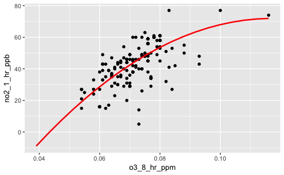

```r
grid3 <- df %>% data_grid(o3_8_hr_ppm = seq_range(o3_8_hr_ppm, 20)) %>% add_predictions(lmModel11_2, "no2_1_hr_ppb")
ggplot(df, mapping = aes(o3_8_hr_ppm, no2_1_hr_ppb)) + geom_point() + geom_line(data = grid3, colour = "red", size = 1)
```

```r
lmModel13 <- lm(no2_1_hr_ppb ~ o3_8_hr_ppm*`x2015_gdp`)
```

```
Dropping 293 rows with missing values
```

```r
summary(lmModel13)
```

```
Call:
lm(formula = no2_1_hr_ppb ~ o3_8_hr_ppm * x2015_gdp)

Residuals:
    Min      1Q  Median      3Q     Max
-37.511  -5.034   2.995   5.766  23.170

Coefficients:
                        Estimate Std. Error t value Pr(>|t|)
(Intercept)           -3.375e+01  5.970e+00  -5.653 4.59e-08 ***
o3_8_hr_ppm            1.034e+03  8.356e+01  12.378  < 2e-16 ***
x2015_gdp              9.479e-05  2.896e-05   3.273  0.00122 **
o3_8_hr_ppm:x2015_gdp -1.034e-03  3.716e-04  -2.782  0.00584 **
---
Signif. codes:  0 ‘***’ 0.001 ‘**’ 0.01 ‘*’ 0.05 ‘.’ 0.1 ‘ ’ 1

Residual standard error: 8.569 on 233 degrees of freedom
  (293 observations deleted due to missingness)
Multiple R-squared:  0.6035,    Adjusted R-squared:  0.5984
F-statistic: 118.2 on 3 and 233 DF,  p-value: < 2.2e-16
```

### The combination of O3 pollution and 2015 GDP along with an interactive term produces a significantly better model. $R^{2} = 0.604$.

### We now look to combine our two best models together to get the best predictive model for NO2 Pollution in an area

```r
lmModel15 <- lm(no2_1_hr_ppb ~ log_pop_2010 + o3_8_hr_ppm*`x2015_gdp`)
```

```
Dropping 293 rows with missing values
```

```r
summary(lmModel15)
```

```
Call:
lm(formula = no2_1_hr_ppb ~ log_pop_2010 + o3_8_hr_ppm * x2015_gdp)

Residuals:
    Min      1Q  Median      3Q     Max
-37.360  -5.323   0.346   4.392  25.952

Coefficients:
                        Estimate Std. Error t value Pr(>|t|)
(Intercept)           -8.006e+01  7.383e+00 -10.844  < 2e-16 ***
log_pop_2010           1.317e+01  1.496e+00   8.803 3.13e-16 ***
o3_8_hr_ppm            6.092e+02  8.711e+01   6.993 2.84e-11 ***
x2015_gdp             -1.019e-05  2.781e-05  -0.366    0.714
o3_8_hr_ppm:x2015_gdp  1.196e-04  3.481e-04   0.344    0.731
---
Signif. codes:  0 ‘***’ 0.001 ‘**’ 0.01 ‘*’ 0.05 ‘.’ 0.1 ‘ ’ 1

Residual standard error: 7.435 on 232 degrees of freedom
  (293 observations deleted due to missingness)
Multiple R-squared:  0.7028,    Adjusted R-squared:  0.6976
F-statistic: 137.1 on 4 and 232 DF,  p-value: < 2.2e-16
```

### We see that 2015 GDP and its interaction term does not produce a statistically significant p-value so we will drop these terms from our model.

```r
library(scatterplot3d)
lmModel16 <- lm(no2_1_hr_ppb ~ log_pop_2010 + o3_8_hr_ppm)
```

```
Dropping 293 rows with missing values
```

```r
summary(lmModel16)
```

```
Call:
lm(formula = no2_1_hr_ppb ~ log_pop_2010 + o3_8_hr_ppm)

Residuals:
    Min      1Q  Median      3Q     Max
-37.311  -5.512   0.477   4.304  25.699

Coefficients:
             Estimate Std. Error t value Pr(>|t|)
(Intercept)  -78.6810     5.2483 -14.992   <2e-16 ***
log_pop_2010  12.6820     0.9629  13.171   <2e-16 ***
o3_8_hr_ppm  628.4343    70.1848   8.954   <2e-16 ***
---
Signif. codes:  0 ‘***’ 0.001 ‘**’ 0.01 ‘*’ 0.05 ‘.’ 0.1 ‘ ’ 1

Residual standard error: 7.407 on 234 degrees of freedom
  (293 observations deleted due to missingness)
Multiple R-squared:  0.7025,    Adjusted R-squared:    0.7
F-statistic: 276.3 on 2 and 234 DF,  p-value: < 2.2e-16
```

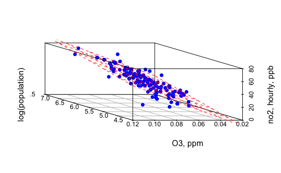

```r
lmPlot <- scatterplot3d(log_pop_2010,o3_8_hr_ppm,no2_1_hr_ppb, xlab = "log(population)", ylab = "O3, ppm", zlab = "no2, hourly, ppb", pch = 16, color = "blue", angle = 330)
lmPlot$plane3d(lmModel16,col = "red")
```

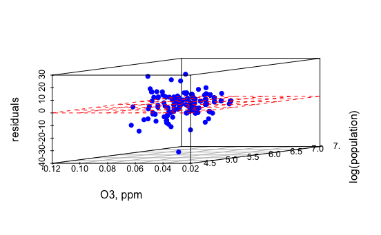

```r
residDF <- df %>% select(log_pop_2010, o3_8_hr_ppm, no2_1_hr_ppb)
residDF <- residDF %>% add_residuals(lmModel16, "resid")
resPlot <- scatterplot3d(x = residDF$log_pop_2010, y = residDF$o3_8_hr_ppm, z = residDF$resid, xlab = "log(population)", ylab = "O3, ppm", zlab = "residuals", pch =16, color = "blue", angle = 200)
resPlot$plane3d(c(0,0,0), col = "red")
```

```r
lmModel16_2 <- lm(no2_am_ppb ~ log_pop_2010 + o3_8_hr_ppm)
```

```
Dropping 279 rows with missing values
```

```r
summary(lmModel16_2)
```

```
Call:
lm(formula = no2_am_ppb ~ log_pop_2010 + o3_8_hr_ppm)

Residuals:
    Min      1Q  Median      3Q     Max
-9.9934 -1.9398 -0.3663  1.2656 15.2702

Coefficients:
             Estimate Std. Error t value Pr(>|t|)
(Intercept)  -41.0483     2.2973 -17.868  < 2e-16 ***
log_pop_2010   6.1625     0.4205  14.654  < 2e-16 ***
o3_8_hr_ppm  212.8919    30.1304   7.066 1.61e-11 ***
---
Signif. codes:  0 ‘***’ 0.001 ‘**’ 0.01 ‘*’ 0.05 ‘.’ 0.1 ‘ ’ 1

Residual standard error: 3.375 on 248 degrees of freedom
  (279 observations deleted due to missingness)
Multiple R-squared:  0.6824,    Adjusted R-squared:  0.6798
F-statistic: 266.4 on 2 and 248 DF,  p-value: < 2.2e-16
```

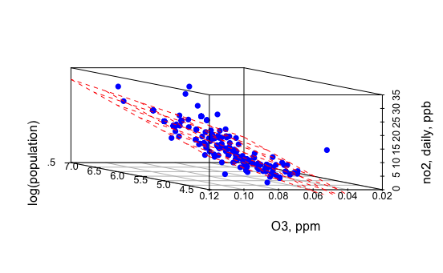

```r
lmPlot <- scatterplot3d(log_pop_2010, o3_8_hr_ppm, no2_am_ppb, xlab = "log(population)", ylab = "O3, ppm", zlab = "no2, daily, ppb", pch = 16, color = "blue", angle = 330)
lmPlot$plane3d(lmModel16_2,col = "red")
```

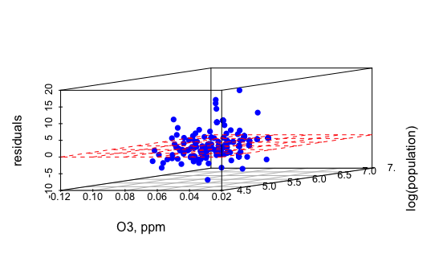

```r
residDF <- df %>% select(log_pop_2010, o3_8_hr_ppm, no2_am_ppb)
residDF <- residDF %>% add_residuals(lmModel16_2, "resid")
resPlot <- scatterplot3d(x = residDF$log_pop_2010, y = residDF$o3_8_hr_ppm, z = residDF$resid, xlab = "log(population)", ylab = "O3, ppm", zlab = "residuals", pch =16, color = "blue", angle = 200)
resPlot$plane3d(c(0,0,0), col = "red")
```

```r
lmModel17 <- lm(no2_am_ppb ~ no2_1_hr_ppb + I(no2_1_hr_ppb^2))
```

```
Dropping 293 rows with missing values
```

```r
summary(lmModel17)
```

```
Call:
lm(formula = no2_am_ppb ~ no2_1_hr_ppb + I(no2_1_hr_ppb^2))

Residuals:
    Min      1Q  Median      3Q     Max
-7.8309 -1.8011 -0.0719  1.1691 10.5767

Coefficients:
                    Estimate Std. Error t value Pr(>|t|)
(Intercept)       -1.0263755  1.2301921  -0.834   0.4050
no2_1_hr_ppb       0.1406429  0.0605830   2.321   0.0211 *
I(no2_1_hr_ppb^2)  0.0031719  0.0007123   4.453 1.31e-05 ***
---
Signif. codes:  0 ‘***’ 0.001 ‘**’ 0.01 ‘*’ 0.05 ‘.’ 0.1 ‘ ’ 1

Residual standard error: 2.419 on 234 degrees of freedom
  (293 observations deleted due to missingness)
Multiple R-squared:  0.8403,    Adjusted R-squared:  0.839
F-statistic: 615.8 on 2 and 234 DF,  p-value: < 2.2e-16
```

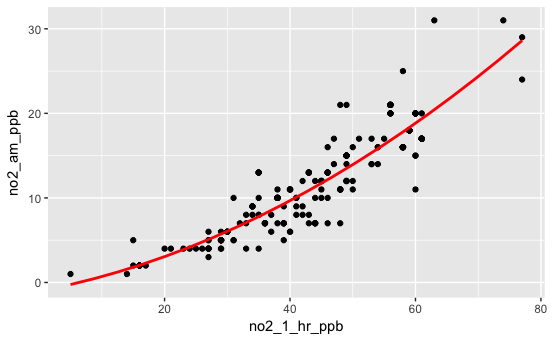

```r
grid4 <- df %>% data_grid(no2_1_hr_ppb = seq_range(no2_1_hr_ppb,20)) %>% add_predictions(lmModel17, "no2_am_ppb")
ggplot(df, mapping=aes(no2_1_hr_ppb, no2_am_ppb)) + geom_point() +  geom_line(data = grid4, col="red", lwd = 1)
```

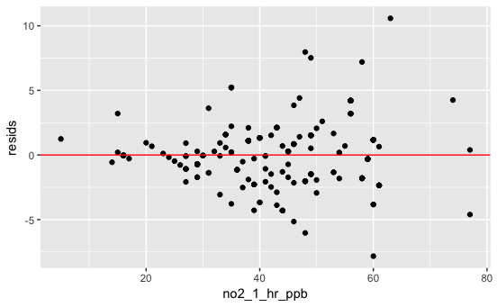

```r
res4 <- df %>% add_residuals(lmModel17,"resids")
ggplot(res4, mapping = aes(no2_1_hr_ppb, resids)) + geom_point() + geom_hline(yintercept = 0, col = "red")
```

### Heteroscedasticity is present in the residual plot. Will try a log transform of the response variable

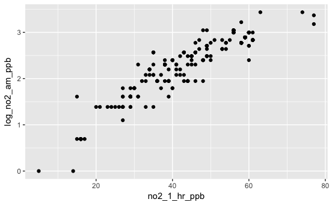

```r
transDf <- df %>% mutate(log_no2_am_ppb = log(no2_am_ppb))
ggplot(transDf, mapping = aes(no2_1_hr_ppb, log_no2_am_ppb)) + geom_point()
```

```r
lmModel17_2 <- lm(log_no2_am_ppb ~ no2_1_hr_ppb + I(no2_1_hr_ppb^2), data = transDf)
```

```
Dropping 293 rows with missing values
```

```r
summary(lmModel17_2)
```

```
Call:
lm(formula = log_no2_am_ppb ~ no2_1_hr_ppb + I(no2_1_hr_ppb^2),
    data = transDf)

Residuals:
     Min       1Q   Median       3Q      Max
-0.64570 -0.10983 -0.01767  0.13992  0.88882

Coefficients:
                    Estimate Std. Error t value Pr(>|t|)
(Intercept)       -5.207e-01  1.123e-01  -4.635 5.92e-06 ***
no2_1_hr_ppb       9.116e-02  5.532e-03  16.477  < 2e-16 ***
I(no2_1_hr_ppb^2) -5.600e-04  6.505e-05  -8.609 1.09e-15 ***
---
Signif. codes:  0 ‘***’ 0.001 ‘**’ 0.01 ‘*’ 0.05 ‘.’ 0.1 ‘ ’ 1

Residual standard error: 0.2209 on 234 degrees of freedom
  (293 observations deleted due to missingness)
Multiple R-squared:  0.886, Adjusted R-squared:  0.885
F-statistic: 909.3 on 2 and 234 DF,  p-value: < 2.2e-16
```

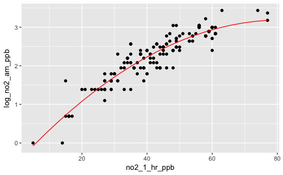

```r
grid5 <- transDf %>% data_grid(no2_1_hr_ppb = seq_range(no2_1_hr_ppb,20)) %>% add_predictions(lmModel17_2, "log_no2_am_ppb")
ggplot(transDf, mapping = aes(no2_1_hr_ppb, log_no2_am_ppb)) + geom_point() + geom_line(data = grid5, col = "red")
```

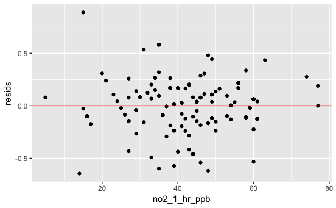

```r
res5 <- transDf %>% add_residuals(lmModel17_2,"resids")
ggplot(res5, mapping = aes(no2_1_hr_ppb, resids)) + geom_point() + geom_hline(yintercept = 0, col = "red")
```